# Homework 4

Francis Olakangil

2023-10-12

1. Using the `Teams` data frame in the Lahman package:
1. (10 points) Make a line plot of total home runs per season and stratify by league. Do you see anything interesting that you observe throughout the years? Create the same plot with changing years axis.

```r
library("Lahman")
library("tidyverse")
```

```r
library("ggplot2")


  Teams_plot <- Teams %>%
    select(yearID, lgID, HR) %>%
    group_by(yearID, lgID) %>%
    summarize(
      total_HR = sum(HR)

    )
      Teams_plot
```

```
## # A tibble: 288 × 3
## # Groups:   yearID [152]
##    yearID lgID  total_HR
##     <int> <fct>    <int>
##  1   1871 NA          47
##  2   1872 NA          37
##  3   1873 NA          47
##  4   1874 NA          40
##  5   1875 NA          40
##  6   1876 NL          40
##  7   1877 NL          24
##  8   1878 NL          23
##  9   1879 NL          58
## 10   1880 NL          62
## # ℹ 278 more rows
```

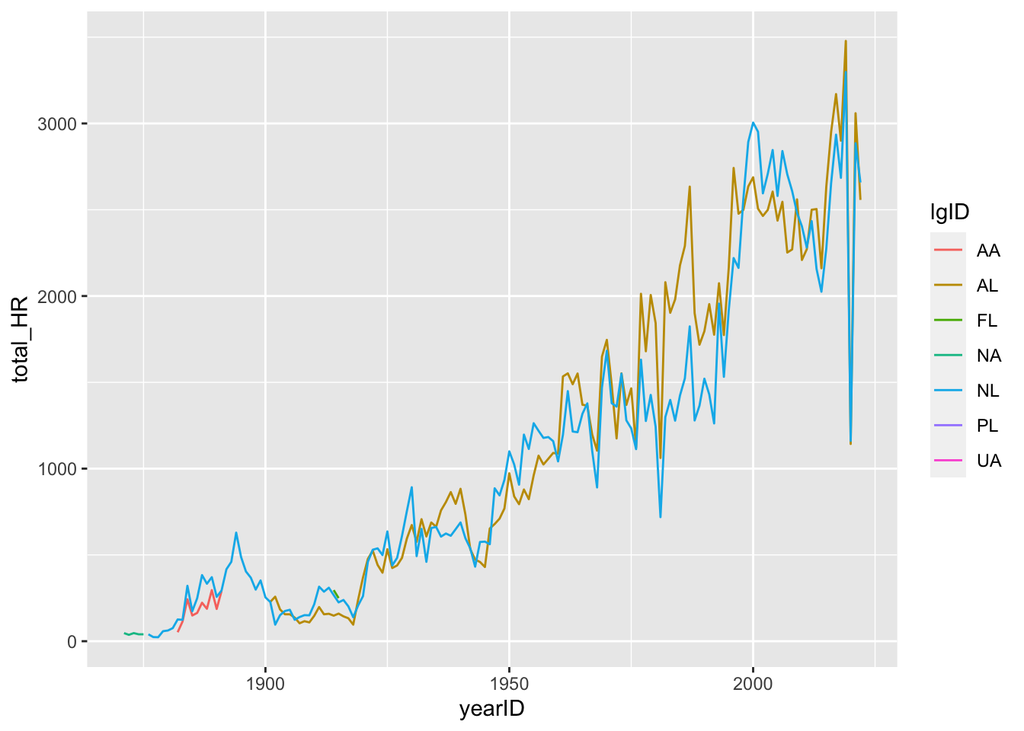

```r
      ggplot(data = Teams_plot, aes(x=yearID, y=total_HR, color=lgID)) +geom_line()
```

b) (10 points) Create an indicator variable called “winning record” which is defined as TRUE if the number of wins is greater than the number of losses and FALSE otherwise. Plot a scatter plot of Runs (R) vs Runs against (RA) with the color of each point showing whether that team had a winning record or not.

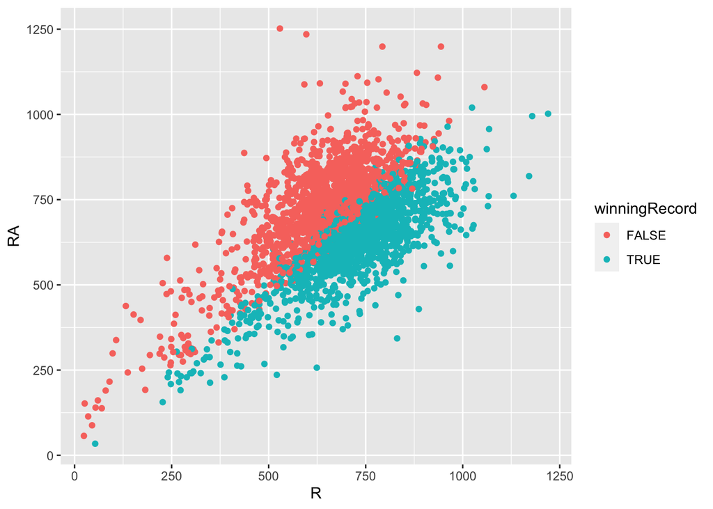

```r
TeamsPlotb <- Teams %>%
  mutate(winningRecord = W/L > 1)

ggplot(data = TeamsPlotb, aes(x=R, y=RA, color = winningRecord)) + geom_point()
```

3. (5 points) Create a scatterplot of strikeouts (SO) vs walks (BB) faceting by Rank 1-5. What do you see?

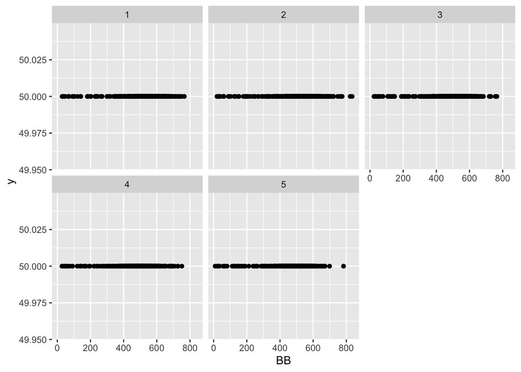

```r
TeamsPlotC <- Teams %>%
  filter(Rank<=5)
g<- ggplot(data = TeamsPlotC, aes(y=50, x= BB))
g+geom_point()+
facet_wrap(~Rank)
```